# normCCS 5–12 级搜索：算法、正确性与实测性能

Bensz Conan

2026-10-29

## 结果与使用建议

CCS 现在支持显式选择 `norm_search_method = "dp"`。它利用原有 RR/NRR 排序上的连续分段结构，避免生成全部切点组合。默认值仍是 `"bruteforce"`，便于复现原有结果；较大的穷举任务会在分配组合矩阵前停止，并提示使用 DP。

在本报告的固定合成数据上，新方法相对原版搜索的实测加速比为 **21.9–44.0 倍**。60 个可穷举问题中，60 个达到相同最优 AUC，最大差距为 0.000000。最大 216 个状态、20 个队列的搜索均完成；耗时、内存和最优映射的哈希见后文和 CSV。

这些结果说明，新搜索减少了本机上这组问题的计算成本。DP 精确求解的是固定方向加权平均 Raw AUC 子问题；原有包含 `All` 的 AUC 中位数及 `OptimizeRank` 通过多初值和局部精修优化，仍可能错过全局最优。诊断字段始终将 `exact_global_optimum` 标为 `FALSE`。

```r
res <- CCS::subtypePerformance(
  data = df, col_subtype = "Subtype", col_tissue = "tumor_type",
  n_norm_subtype = 8,
  norm_search_method = "dp",
  norm_roc_method = "Raw", norm_rank_marker = "NRR",
  numCores = 1, verbose = TRUE
)
res$Data$Normalization$Summary[1, ]
res$Data$Normalization$SearchDiagnostics
```

## 为什么旧搜索慢

设实际出现的分子状态数为 M，合并后等级数为 K。原算法在预先确定的排序上选 K−1 个切点，产生 `choose(M−1, K−1)` 种连续分段。每种分段都重新映射所有样本，生成 `Info` 字符串，计算合并样本和各队列的 ROC，并保存所有结果。耗时和结果表大小都随组合数增长。

新实现保留排序和分级标签。最高应答倾向的区间仍编码为 K−1，最低为 0；`Info` 仍按 `0=...; 1=...` 输出。新搜索先把样本压缩为“队列 × 排序状态”的应答与未应答计数，对大量分段批量评分，最终只为少量候选生成完整结果。

## 算法依据与评分细节

对每个队列，Pᵢ 和 Nᵢ 分别为排序状态 i 中的应答与未应答人数。排序从高分到低分；固定 ROC 方向下，原始状态的 AUC 分子为：

公式采用 0 为对照、1 为应答的通常编码；factor 结局则按其 levels 保持 pROC 的原有方向。

$$U=\sum_i P_i\left(\sum_{j>i}N_j+\tfrac12N_i\right).$$

把连续区间 [a,b] 合为一个等级，会把区间内部比较变为并列。因此该区间相对于原评分的损失为：

$$L(a,b)=U(a,b)-\tfrac12P(a,b)N(a,b).$$

人数前缀和可在常数时间计算区间损失。对各队列归一化并加权后，K 个区间的总损失可加，动态规划以 O(KM²) 时间求出该加权目标的全局最优分段。队列内状态顺序有冲突时，损失可以为负；代码保留这一性质，没有截断为零。数据结构约为 O(CM²+KM)，不随全部切分组合数增长。

多组确定性权重分别照顾合并数据、队列平均和单队列，并提供反向评分初值；另加入等宽初值。按遗留中位数目标挑选前六个初值，对每个切点遍历相邻切点之间的所有合法位置；单切点没有改善时，再联动搜索两个相邻切点，最多精修十轮。只有目标改善超过 1e−12 才移动切点。双切点候选每批最多 512 个，限制临时内存。该策略保证每条精修路径不降低目标，但局部最优仍不等于全局最优；是否达到局部收敛记录在诊断中。

快速评分明确复现了 pROC 的自动方向：先比较应答与未应答人群的分数中位数，再决定是否翻转 AUC。它不是简单取 `max(AUC, 1−AUC)`。`OptimizeRank` 还会计算每个等级的 one-vs-rest AUC，保留首次出现次序以打破并列，再按重排后的等级评分。二级继续遵循旧代码的二分类分支。返回结果前，所有最终候选均调用原有 `get_perform_markers()`，要求 AUC 与快速评分的误差不超过 1e−10；不一致则报错。

## 测试数据与正确性

所有输入均由 `fixtures.R` 生成，没有读取患者、基因组或历史研究队列文件。固定种子控制队列基线、状态人数、应答概率、部分队列反向趋势和样本排列；部分队列缺少部分状态，个别状态全应答或全未应答。每个队列始终含两类结局，样本 ID 唯一。生成器恢复调用者的随机数状态。

验证分为三层。冻结的 `reference/subtype-norm-0.8.4.R` 用于核对 K=2、3、4，四种排序方式及 `Raw`／`OptimizeRank` 下默认与显式穷举的结果表。小问题的所有分段逐项比较快速评分与原 ROC 函数，并比较 DP 的加权目标与完整穷举的最优值。更大的随机合成问题则统计遗留中位数目标的差距，而不把它宣称为精确 DP。

合成问题的遗留中位数 AUC：M=10、C=4、K=4/5/6，10 个固定种子

|  | Method | Cases | Exact_matches | Within_0.005 | Worst_gap | Median_gap | Max_refinement_gain |
| --- | --- | --- | --- | --- | --- | --- | --- |
| OptimizeRank | OptimizeRank | 30 | 30 | 30 | 0 | 0 | 0.068194 |
| Raw | Raw | 30 | 30 | 30 | 0 | 0 | 0.025683 |

这里的 gap 等于“穷举最优 AUC − DP 最优 AUC”，越小越好；0.005 是计划中的工程比较尺度，并非统计显著性阈值。比较对象是同一合成数据上的确定性搜索结果，因此不计算 AUC 总体推断区间或 p 值。完整逐问题结果保存在 `products/quality.csv`，包括未达到阈值的情况；不能把固定种子中的匹配比例当作所有真实数据的保证。

最初只移动一个切点，Raw 模式尚有两个问题未达到穷举最优，`OptimizeRank` 的最差差距也较大。因此增加了相邻双切点联动：允许两个边界一起改变，跨过单独移动任一边界都无法改善的局部位置。下表按相同种子、状态数、队列数和 K 对齐两轮结果；原始记录保存在 `reference/quality-single-cut.csv`。这次改进针对已观察到的合成问题，不能把再次匹配解释为对未知数据的无偏成功率估计。

算法迭代：单切点精修与增加双切点后的结果

|  | Method | Cases | Single_exact | Pair_exact | Single_worst_gap | Pair_worst_gap |
| --- | --- | --- | --- | --- | --- | --- |
| OptimizeRank | OptimizeRank | 30 | 25 | 30 | 0.025490 | 0 |
| Raw | Raw | 30 | 28 | 30 | 0.002341 | 0 |

## 实测加速与资源

性能基准使用 M=12、C=4 的同一份数据，分别运行原版搜索和 DP，每种配置重复 3 次。每次在新的 R 进程加载同一份 CCS 源码及依赖，计时仅包围搜索调用，包含排序、候选生成、评分和结果整理。原版固定一个 worker；DP 使用一个进程，不启动 worker，也不修改调用者的并行后端。表中列出测量的中位数及配对加速比中位数。

运行设备为 Windows、Intel Core i9-14900K，32 个逻辑核、约 64 GiB RAM；所有基准均将搜索限制为单核。R 版本为项目指定的 4.3.1，ROC 参考实现为 pROC 1.18.5。

原版与 DP 的直接实测；时间单位为秒

| K | method | elapsed_seconds.legacy | elapsed_seconds.dp | speedup | gap |
| --- | --- | --- | --- | --- | --- |
| 4 | OptimizeRank | 8.53 | 0.39 | 21.8718 | 0.0000 |
| 5 | OptimizeRank | 12.83 | 0.42 | 30.5476 | 0.0000 |
| 6 | OptimizeRank | 17.08 | 0.44 | 38.8182 | 0.0034 |
| 4 | Raw | 6.08 | 0.17 | 35.7647 | 0.0000 |
| 5 | Raw | 7.33 | 0.18 | 40.7222 | 0.0000 |
| 6 | Raw | 8.41 | 0.19 | 44.0000 | 0.0000 |

这份计时数据使用另一固定种子，未用于前一轮精修策略比较。其中最大的 AUC 差距为 0.003425，出现在 K=6 的 OptimizeRank 模式。这也说明，质量基准上的全部匹配不能保证新问题仍达到穷举最优。

加速主要来自减少重复工作和组合枚举，不依赖堆叠 CPU。加速比中包含原版建立 worker、传输数据和整理全部候选的成本，这也是旧接口一次实际调用的组成部分；R 包加载不计入耗时。这里只有三次重复，计时属于本机描述性工程测量，不报告看似精确的置信区间。

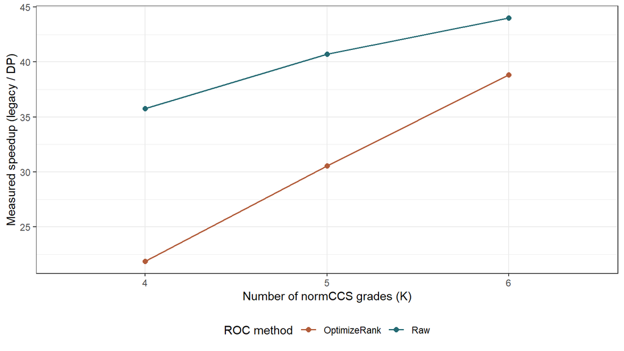

图中横轴是输出等级数，纵轴表示原版耗时除以 DP 耗时；每个点对应上表的一组实测。随着合法切分数量增加，原版需要评估更多候选，而 DP 的主要结构仍受状态数和等级数约束。两种 ROC 模式的差异还取决于类别重排与最终复核成本，不能仅按组合数量外推真实耗时。

## 107／216 状态、20 队列的 5–12 级搜索

高维搜索实测；峰值和区间数据结构以 MiB 计

| M | C | K | method | nSample | partitions | candidates | elapsed_seconds | master_peak_mib | interval_mib | median_auc |
| --- | --- | --- | --- | --- | --- | --- | --- | --- | --- | --- |
| 107 | 20 | 5 | Raw | 24424 | 4.967690e+06 | 9 | 5.67 | 1106.586 | 3.931 | 0.703 |
| 107 | 20 | 5 | OptimizeRank | 24424 | 4.967690e+06 | 9 | 7.07 | 1127.711 | 3.931 | 0.704 |
| 107 | 20 | 6 | Raw | 24424 | 1.013409e+08 | 10 | 5.57 | 1088.570 | 3.931 | 0.705 |
| 107 | 20 | 6 | OptimizeRank | 24424 | 1.013409e+08 | 12 | 8.84 | 1123.688 | 3.931 | 0.707 |
| 107 | 20 | 8 | Raw | 24424 | 2.437007e+10 | 11 | 5.28 | 1110.699 | 3.931 | 0.707 |
| 107 | 20 | 8 | OptimizeRank | 24424 | 2.437007e+10 | 12 | 8.78 | 1134.031 | 3.931 | 0.714 |
| 107 | 20 | 10 | Raw | 24424 | 3.283867e+12 | 12 | 5.84 | 1119.867 | 3.931 | 0.709 |
| 107 | 20 | 10 | OptimizeRank | 24424 | 3.283867e+12 | 12 | 11.20 | 1133.953 | 3.931 | 0.719 |
| 107 | 20 | 12 | Raw | 24424 | 2.779942e+14 | 12 | 5.33 | 1132.789 | 3.931 | 0.709 |
| 107 | 20 | 12 | OptimizeRank | 24424 | 2.779942e+14 | 12 | 12.83 | 1140.555 | 3.931 | 0.728 |
| 216 | 20 | 5 | Raw | 49098 | 8.656782e+07 | 12 | 15.37 | 1155.223 | 15.471 | 0.691 |
| 216 | 20 | 5 | OptimizeRank | 49098 | 8.656782e+07 | 12 | 21.47 | 1202.465 | 15.471 | 0.693 |
| 216 | 20 | 6 | Raw | 49098 | 3.653162e+09 | 12 | 16.30 | 1158.645 | 15.471 | 0.693 |
| 216 | 20 | 6 | OptimizeRank | 49098 | 3.653162e+09 | 11 | 26.53 | 1217.035 | 15.471 | 0.696 |
| 216 | 20 | 8 | Raw | 49098 | 3.817554e+12 | 12 | 15.31 | 1170.406 | 15.471 | 0.696 |
| 216 | 20 | 8 | OptimizeRank | 49098 | 3.817554e+12 | 12 | 24.06 | 1203.262 | 15.471 | 0.702 |
| 216 | 20 | 10 | Raw | 49098 | 2.282897e+15 | 12 | 18.25 | 1169.551 | 15.471 | 0.697 |
| 216 | 20 | 10 | OptimizeRank | 49098 | 2.282897e+15 | 12 | 29.41 | 1201.508 | 15.471 | 0.706 |
| 216 | 20 | 12 | Raw | 49098 | 8.764250e+17 | 12 | 17.75 | 1173.281 | 15.471 | 0.698 |
| 216 | 20 | 12 | OptimizeRank | 49098 | 8.764250e+17 | 12 | 31.61 | 1238.000 | 15.471 | 0.710 |

这张表的耗时全部来自实际运行，旧版在这些规模下未运行；`partitions` 只用于说明合法空间大小，不能据此把推算的旧版耗时当成实测加速。每一配置只测一次，结果适合判断能否运行及资源量级。峰值为 Windows 报告的 R 主进程历史最大工作集，包含加载依赖；DP 没有子进程。`interval_mib` 是计数、区间代价和相关模型对象的 R 对象大小，不是总内存峰值。完整映射指纹和切点保存在 `products/scaling.csv`。

## 增加等级后的样本支持

216 状态合成数据的队列 × 等级人数与应答支持

|  | K | Cohort_grade_cells | Empty | Under_10 | No_responders | Minimum_n | Median_n |
| --- | --- | --- | --- | --- | --- | --- | --- |
| 5 | 5 | 100 | 0 | 0 | 0 | 282 | 375.5 |
| 8 | 8 | 160 | 0 | 0 | 0 | 137 | 309.5 |
| 12 | 12 | 240 | 0 | 1 | 1 | 9 | 217.5 |

更高的 K 会把部分区间分得更细。表中的空等级、小样本等级或无应答者等级，反映了仅优化 AUC 中位数没有约束每个等级的样本量。它们提醒后续研究同时检查分级稳定性和校准。这里未加入计划之外的最低组规模约束，也没有使用合成结果主张临床获益。

## 代码变更与复现

`R/phenotype.R` 追加算法参数、向下传递并写入 `Repeat`，共用原有排序；`R/subtype_norm_dp.R` 提供计数、区间损失、动态规划、批量评分、精修和最终 ROC 复核。没有新增 C++、编译工具链或并行依赖。缺失关键字段、非二分类标签、单结局队列、无效等级数和核数在搜索前报错，`All` 保留为汇总行名称。默认穷举保留原有输出；DP 的 `Raw`／`Summary` 只含实际复核的最终候选，另附诊断信息，不能当作全部候选表。

从仓库根目录使用项目指定的 R 4.3.1：

```powershell
& 'C:/R/R-4.3.1/bin/Rscript.exe' --vanilla test/normCCS-5-more/test-search.R
& 'C:/R/R-4.3.1/bin/Rscript.exe' --vanilla test/normCCS-5-more/benchmark.R
& 'C:/R/R-4.3.1/bin/Rscript.exe' --vanilla test/normCCS-5-more/render-report.R
```

这是已有 R 包中的 simple 场景测试，没有另建 targets 流程，也不改动其它分析的 store 或 renv。`00.Environment.R` 统一加载依赖，`session-info.txt` 保存实际包版本。隔离轻量测试另见 `scripts/tests/smoke-test.R`；完整的组件测试、包构建和检查记录在 `verification.md` 中。本报告只读取 benchmark 生成的结果，不在渲染时重算搜索。真实患者全量验证为 **NOT_RUN**；真实队列 AUC、跨队列泛化、校准与临床稳定性均不在本次工程测试的证据范围内。